# Notas de Aula - Introdução à Inferência Estatística

# 8 Testes T de uma amostra

Um teste de hipótese é um procedimento estatístico utilizado para tomar decisões sobre uma característica populacional com base em dados amostrais.

## 8.1 Estrutura do Teste

- **Hipótese Nula (H₀):** Afirma que não há efeito ou diferença.
- **Hipótese Alternativa (H₁):** Afirma que há um efeito ou diferença.

A significância do teste é geralmente estabelecida em 5% (α = 0,05), indicando a probabilidade de rejeitar a hipótese nula quando ela é verdadeira. Dependendo do valor de p, que é comparado com o nível de significância, decidimos se rejeitamos ou aceitamos a hipótese nula.

## 8.2 Erros Tipo 1 e Tipo 2

- **Erro Tipo 1 (Falso Positivo):** Rejeitar H₀ quando H₀ é verdadeira.
- **Erro Tipo 2 (Falso Negativo):** Não rejeitar H₀ quando H₁ é verdadeira.

### 8.2.1 Poder Estatístico

O poder estatístico é a probabilidade de detectar um efeito, caso ele exista, e está relacionado ao tamanho da amostra e ao nível de significância.

## 8.3 Distribuição T-Student

A distribuição T-Student é usada para estimar a média populacional quando o tamanho da amostra é pequeno e o desvio padrão populacional é desconhecido. É mais apropriada em amostras pequenas, onde o desvio padrão amostral (S) é utilizado em vez do desvio padrão populacional (σ), corrigindo o viés de subestimação do desvio padrão.

### 8.3.1 Comparação de Médias

A distribuição T-Student permite comparar a média amostral com a média populacional hipotética. Para isso, ajusta-se o teste para o tamanho da amostra.

## 8.4 Simulação da Distribuição T-Student

A distribuição T-Student é derivada da distribuição amostral da média. Para amostras pequenas, a distribuição dos t’s observados segue a distribuição T-Student com graus de liberdade (n - 1), onde n é o tamanho da amostra.

## 8.5 Comparação de Médias

Para comparar uma média amostral com uma média hipotética, definem-se a hipótese nula e a hipótese alternativa, constrói-se a distribuição regida pela hipótese nula, e identificam-se as regiões de aceitação e rejeição.

### 8.5.1 Exemplo Prático em R

Vamos realizar um teste de hipótese usando a distribuição T-Student para comparar uma média amostral com uma média populacional hipotética.

```r
# Exemplo de comparação de média amostral com média hipotética usando a distribuição T-Student

# Dados
set.seed(123)  # Para reprodutibilidade
amostra <- rnorm(20, mean = 50, sd = 10)  # Amostra de tamanho 20 com média 50 e desvio padrão 10

# Média amostral
media_amostral <- mean(amostra)
desvio_padrao_amostral <- sd(amostra)

# Hipótese
media_hipotetica <- 55
nivel_significancia <- 0.05

# Cálculo do valor t
n <- length(amostra)
graus_liberdade <- n - 1
valor_t <- (media_amostral - media_hipotetica) / (desvio_padrao_amostral / sqrt(n))

# Valor-p
valor_p <- 2 * (1 - pt(abs(valor_t), df = graus_liberdade))

# Resultados
cat("Média Amostral:", media_amostral, "\n")
```

```
## Média Amostral: 51.41624
```

```r
cat("Desvio Padrão Amostral:", desvio_padrao_amostral, "\n")
```

```
## Desvio Padrão Amostral: 9.726653
```

```r
cat("Valor t:", valor_t, "\n")
```

```
## Valor t: -1.647748
```

```r
cat("Valor-p:", valor_p, "\n")
```

```
## Valor-p: 0.1158429
```

```r
cat("Rejeitar H0?", ifelse(valor_p < nivel_significancia, "Sim", "Não"), "\n")
```

```
## Rejeitar H0? Não
```

Neste exemplo, foi gerada uma amostra de 20 observações de uma distribuição normal com média 50 e desvio padrão 10. Comparamos a média amostral com uma média hipotética de 55 usando a distribuição T-Student. Calculamos o valor t e o valor-p para determinar se rejeitamos a hipótese nula com base no nível de significância de 5%.

## 8.6 Intervalos de Confiança e Bootstrap

**Intervalos de Confiança** são usados como uma alternativa gráfica para a análise de testes de hipótese. Se a média populacional hipotética está dentro do intervalo de confiança da média amostral, é consistente com a aceitação da hipótese nula.

**Método Bootstrap** é uma técnica de reamostragem que não requer a premissa de normalidade dos dados. Pode ser utilizado para avaliar a variabilidade da estatística amostral, especialmente quando as premissas paramétricas não são atendidas.

# 9 Teste t pareado / teste qui-quadrado para variância

## 9.1 1. Teste t Pareado

- Usado para comparar a média de duas medições relacionadas. O exemplo mostra a diferença na pressão arterial antes e depois do tratamento.

### 9.1.1 Exemplo Prático em R

Usando um exemplo semelhante ao apresentado: medindo a pressão arterial de pacientes antes e depois de um tratamento.

```r
# Dados das amostras pareadas
pressao_antes <- c(120, 130, 125, 140, 135, 128, 132, 138, 126, 127)
pressao_depois <- c(115, 125, 120, 135, 130, 123, 128, 134, 122, 126)

# Teste t pareado
resultado_t_pareado <- t.test(pressao_antes, pressao_depois, paired = TRUE)

# Resultados
cat("Teste t Pareado\n")
```

```
## Teste t Pareado
```

```r
cat("Estatístico t:", resultado_t_pareado$statistic, "\n")
```

```
## Estatístico t: 10.86376
```

```r
cat("P-valor:", resultado_t_pareado$p.value, "\n")
```

```
## P-valor: 1.788198e-06
```

```r
cat("Intervalo de Confiança para a Diferença de Médias:", resultado_t_pareado$conf.int, "\n")
```

```
## Intervalo de Confiança para a Diferença de Médias: 3.404612 5.195388
```

```r
cat("Média da pressão antes do tratamento:", mean(pressao_antes), "\n")
```

```
## Média da pressão antes do tratamento: 130.1
```

```r
cat("Média da pressão depois do tratamento:", mean(pressao_depois), "\n")
```

```
## Média da pressão depois do tratamento: 125.8
```

```r
# Decisão do teste
if (resultado_t_pareado$p.value < 0.05) {
  cat("Rejeita-se a hipótese nula. Há evidências suficientes para afirmar que há uma diferença significativa nas médias das pressões arteriais antes e depois do tratamento.\n")
} else {
  cat("Não se rejeita a hipótese nula. Não há evidências suficientes para afirmar que há uma diferença significativa nas médias das pressões arteriais antes e depois do tratamento.\n")
}
```

```
## Rejeita-se a hipótese nula. Há evidências suficientes para afirmar que há uma diferença significativa nas médias das pressões arteriais antes e depois do tratamento.
```

## 9.2 2. Teste Qui-Quadrado para Variância

- Verifica se a variância de uma amostra é diferente de uma variância conhecida. No exemplo, usamos notas de um exame e uma variância conhecida.

### 9.2.1 Exemplo Prático em R

```r
# Dados da amostra
notas <- c(85, 88, 90, 91, 92, 86, 87, 89, 95, 93)

# Variância conhecida
variancia_conhecida <- 100

# Calcular a variância da amostra
variancia_amostra <- var(notas)

# Número de observações
n <- length(notas)

# Teste Qui-Quadrado
resultado_qui2 <- (n - 1) * variancia_amostra / variancia_conhecida
p_valor_qui2 <- pchisq(resultado_qui2, df = n - 1, lower.tail = FALSE)

# Resultados
cat("Teste Qui-Quadrado para Variância\n")
```

```
## Teste Qui-Quadrado para Variância
```

```r
cat("Estatístico Qui-Quadrado:", resultado_qui2, "\n")
```

```
## Estatístico Qui-Quadrado: 0.924
```

```r
cat("P-valor:", p_valor_qui2, "\n")
```

```
## P-valor: 0.9995936
```

```r
# Decisão do teste
if (p_valor_qui2 < 0.05) {
  cat("Rejeita-se a hipótese nula. Há evidências suficientes para afirmar que a variância das notas é diferente da variância conhecida.\n")
} else {
  cat("Não se rejeita a hipótese nula. Não há evidências suficientes para afirmar que a variância das notas é diferente da variância conhecida.\n")
}
```

```
## Não se rejeita a hipótese nula. Não há evidências suficientes para afirmar que a variância das notas é diferente da variância conhecida.
```

## 9.3 3. Mão na Massa com Dados Reais

- Compara as médias de dois grupos independentes. O exemplo usa o conjunto de dados `mtcars` para comparar o consumo de combustível (mpg) entre carros com diferentes números de cilindros.

Esses exemplos ajudam a aplicar e entender os testes de hipótese com dados reais e simulados. Se precisar de mais informações ou tiver dúvidas, estou à disposição!

### 9.3.1 Exemplo Prático em R

Vamos aplicar o teste t de duas amostras independentes ao conjunto de dados `mtcars` para comparar as médias de mpg entre carros com 4 e 6 cilindros.

```r
# Carregar o conjunto de dados
data(mtcars)

# Separar os dados em dois grupos com base no número de cilindros
mpg_4_cilindros <- mtcars[mtcars$cyl == 4, "mpg"]
mpg_6_cilindros <- mtcars[mtcars$cyl == 6, "mpg"]

# Teste t de duas amostras independentes
resultado_t_independente_real <- t.test(mpg_4_cilindros, mpg_6_cilindros, var.equal = TRUE)

# Resultados
cat("Teste t de Duas Amostras Independentes com Dados Reais\n")
```

```
## Teste t de Duas Amostras Independentes com Dados Reais
```

```r
cat("Estatístico t:", resultado_t_independente_real$statistic, "\n")
```

```
## Estatístico t: 3.895241
```

```r
cat("P-valor:", resultado_t_independente_real$p.value, "\n")
```

```
## P-valor: 0.001286608
```

```r
cat("Intervalo de Confiança para a Diferença de Médias:", resultado_t_independente_real$conf.int, "\n")
```

```
## Intervalo de Confiança para a Diferença de Médias: 3.154286 10.68727
```

```r
cat("Média do mpg com 4 cilindros:", mean(mpg_4_cilindros), "\n")
```

```
## Média do mpg com 4 cilindros: 26.66364
```

```r
cat("Média do mpg com 6 cilindros:", mean(mpg_6_cilindros), "\n")
```

```
## Média do mpg com 6 cilindros: 19.74286
```

```r
# Decisão do teste
if (resultado_t_independente_real$p.value < 0.05) {
  cat("Rejeita-se a hipótese nula. Há evidências suficientes para afirmar que as médias de mpg para carros com 4 e 6 cilindros são diferentes.\n")
} else {
  cat("Não se rejeita a hipótese nula. Não há evidências suficientes para afirmar que as médias de mpg para carros com 4 e 6 cilindros são diferentes.\n")
}
```

```
## Rejeita-se a hipótese nula. Há evidências suficientes para afirmar que as médias de mpg para carros com 4 e 6 cilindros são diferentes.
```

# 10 Teste t para duas amostras independentes

O objetivo desta aula é entender e aplicar métodos para comparar médias entre duas populações. Vamos focar principalmente no teste t de Student e no teste de permutação.

## 10.1 Conceitos Teóricos

### 10.1.1 Distribuição t de Student

A distribuição t de Student é usada quando estamos lidando com amostras pequenas e não conhecemos a variância populacional. Ela se torna semelhante à distribuição normal à medida que o tamanho da amostra aumenta.

- **Teorema Central do Limite:** Afirma que a distribuição das médias amostrais tende a ser normal à medida que o tamanho da amostra aumenta, mesmo que a distribuição da população não seja normal.
- **Erro Padrão:** Mede a variabilidade da média amostral em relação à média populacional e é calculado como $\frac{s}{\sqrt{n}}$, onde $s$ é o desvio padrão da amostra e $n$ é o tamanho da amostra.

### 10.1.2 Teste t para Amostras Independentes

Este teste é utilizado para comparar as médias de duas amostras independentes. Existem duas variantes dependendo das premissas sobre a variância das amostras:

1. **Assumindo variâncias iguais (Teste t de variâncias iguais):**
   - **Hipóteses:**
     - $H_0$: $\mu_1 = \mu_2$ (As médias são iguais)
     - $H_1$: $\mu_1 \neq \mu_2$ (As médias são diferentes)
   - **Estatístico t:**
     $$t = \frac{\bar{x}_1 - \bar{x}_2}{s_p \sqrt{\frac{1}{n_1} +
     \frac{1}{n_2}}}$$
     onde $s_p$ é a variância combinada.
2. **Assumindo variâncias diferentes (Teste t de variâncias diferentes):**
   - O cálculo do valor t e dos graus de liberdade é ajustado para levar em conta as variâncias desiguais.

### 10.1.3 Teste de Permutação

O teste de permutação é uma alternativa ao teste t quando as premissas do teste t não são atendidas, como distribuições não normais.

- **Procedimento:**
  1. Embaralhar aleatoriamente as observações entre os grupos.
  2. Calcular a diferença entre as médias para cada permutação.
  3. Construir uma distribuição empírica da diferença sob a hipótese nula.
  4. Calcular o p-valor com base nessa distribuição empírica.

## 10.2 Exemplos Práticos em R

### 10.2.1 Teste t para Amostras Independentes

Vamos considerar dois grupos de amostras com variâncias iguais e diferentes.

```r
# Dados das amostras
grupo1 <- c(23, 27, 22, 24, 26, 28, 25)
grupo2 <- c(31, 30, 29, 33, 32, 31, 30)

# Teste t para variâncias iguais
resultado_t_igual <- t.test(grupo1, grupo2, var.equal = TRUE)

# Teste t para variâncias diferentes
resultado_t_diferente <- t.test(grupo1, grupo2, var.equal = FALSE)

# Resultados
cat("Teste t para variâncias iguais\n")
```

```
## Teste t para variâncias iguais
```

```r
cat("Estatístico t:", resultado_t_igual$statistic, "\n")
```

```
## Estatístico t: -6.089407
```

```r
cat("P-valor:", resultado_t_igual$p.value, "\n")
```

```
## P-valor: 5.422786e-05
```

```r
cat("Teste t para variâncias diferentes\n")
```

```
## Teste t para variâncias diferentes
```

```r
cat("Estatístico t:", resultado_t_diferente$statistic, "\n")
```

```
## Estatístico t: -6.089407
```

```r
cat("P-valor:", resultado_t_diferente$p.value, "\n")
```

```
## P-valor: 0.0001151464
```

### 10.2.2 Teste de Permutação

Vamos aplicar o teste de permutação ao mesmo conjunto de dados.

```r
# Função para calcular a diferença de médias
diferenca_medias <- function(x, y) {
  abs(mean(x) - mean(y))
}

# Dados das amostras
grupo1 <- c(23, 27, 22, 24, 26, 28, 25)
grupo2 <- c(31, 30, 29, 33, 32, 31, 30)

# Diferença de médias observada
obs_diff <- diferenca_medias(grupo1, grupo2)

# Número de permutações
n_perm <- 10000

# Combinar os dados
dados_combinados <- c(grupo1, grupo2)

# Permutação
set.seed(123)
diferencas_permutadas <- replicate(n_perm, {
  amostras_permutadas <- sample(dados_combinados)
  grupo1_perm <- amostras_permutadas[1:length(grupo1)]
  grupo2_perm <- amostras_permutadas[(length(grupo1) + 1):length(dados_combinados)]
  diferenca_medias(grupo1_perm, grupo2_perm)
})

# P-valor
p_valor_perm <- mean(diferencas_permutadas >= obs_diff)

# Resultados
cat("Teste de Permutação\n")
```

```
## Teste de Permutação
```

```r
cat("Diferença de médias observada:", obs_diff, "\n")
```

```
## Diferença de médias observada: 5.857143
```

```r
cat("P-valor:", p_valor_perm, "\n")
```

```
## P-valor: 0.001
```

### 10.2.3 Aplicação Prática: Comparação de Máquinas de Embalagem de Café

Vamos comparar duas máquinas de embalagem de café com base na quantidade de pacotes produzidos.

```r
# Dados das amostras
maquina1 <- c(150, 155, 160, 158, 157)
maquina2 <- c(170, 165, 172, 168, 169)

# Teste t
resultado_t_maquinas <- t.test(maquina1, maquina2, var.equal = TRUE)

# Resultados
cat("Comparação de Máquinas de Embalagem de Café\n")
```

```
## Comparação de Máquinas de Embalagem de Café
```

```r
cat("Estatístico t:", resultado_t_maquinas$statistic, "\n")
```

```
## Estatístico t: -6.21623
```

```r
cat("P-valor:", resultado_t_maquinas$p.value, "\n")
```

```
## P-valor: 0.0002548848
```

```r
# Teste de Permutação
obs_diff_maquinas <- diferenca_medias(maquina1, maquina2)
dados_combinados_maquinas <- c(maquina1, maquina2)
diferencas_permutadas_maquinas <- replicate(n_perm, {
  amostras_permutadas <- sample(dados_combinados_maquinas)
  maquina1_perm <- amostras_permutadas[1:length(maquina1)]
  maquina2_perm <- amostras_permutadas[(length(maquina1) + 1):length(dados_combinados_maquinas)]
  diferenca_medias(maquina1_perm, maquina2_perm)
})
p_valor_perm_maquinas <- mean(diferencas_permutadas_maquinas >= obs_diff_maquinas)

cat("P-valor do teste de permutação para máquinas:", p_valor_perm_maquinas, "\n")
```

```
## P-valor do teste de permutação para máquinas: 0.009
```

# 11 Teste F de igualdade de variância

Nesta aula, abordamos o desenvolvimento histórico da estatística, suas aplicações em diferentes áreas científicas, e os métodos estatísticos relevantes, com foco no teste F e outros testes associados.

## 11.1 Estatístico Ronald Fisher

Ronald Fisher é uma figura central no desenvolvimento da estatística moderna. Ele fez contribuições significativas para a estatística aplicada à genética e evolução, desenvolvendo métodos para lidar com múltiplos fatores e variabilidades. Fisher é conhecido por desenvolver o teste F, entre outros métodos estatísticos.

### 11.1.1 Contribuições de Ronald Fisher

- **Desenvolvimento de Métodos Estatísticos:** Fisher desenvolveu vários testes e conceitos fundamentais, como o teste F, para comparar variâncias e avaliar hipóteses em estudos genéticos e evolutivos.
- **Teoria da Distribuição F:** A distribuição F é utilizada para comparar variâncias de duas amostras e é fundamental para o teste F.

## 11.2 Conceitos de Razão F, Teste F e Distribuição F

### 11.2.1 Razão F

A razão F é a razão entre as variâncias de duas amostras e é usada para avaliar se as variâncias são iguais.

### 11.2.2 Teste F

O teste F utiliza a distribuição F para comparar as variâncias de duas populações. As hipóteses são:

- $H_0$: As variâncias das duas populações são iguais.
- $H_1$: As variâncias das duas populações são diferentes.

### 11.2.3 Distribuição F

A distribuição F descreve a distribuição das razões de variância e é usada para determinar a significância dos resultados do teste F.

## 11.3 Exemplo Prático: Comparação da Variabilidade na Produção de Parafusos

Vamos comparar a variabilidade na produção de parafusos por duas máquinas diferentes usando o teste F.

```r
# Dados das amostras
maquina1 <- c(5.1, 5.3, 5.2, 5.4, 5.3)
maquina2 <- c(5.8, 5.7, 5.9, 6.0, 5.8)

# Teste F
resultado_f <- var.test(maquina1, maquina2)

# Resultados
cat("Teste F\n")
```

```
## Teste F
```

```r
cat("Estatístico F:", resultado_f$statistic, "\n")
```

```
## Estatístico F: 1
```

```r
cat("P-valor:", resultado_f$p.value, "\n")
```

```
## P-valor: 1
```

## 11.4 Utilização de Métodos de Reamostragem: Teste de Permutação

Quando as premissas do teste F não são atendidas, métodos de reamostragem como o teste de permutação podem ser utilizados. Vamos realizar o teste de permutação para comparar variâncias.

```r
# Função para calcular a razão de variâncias
razão_variancias <- function(x, y) {
  var(x) / var(y)
}

# Dados das amostras
dados_combinados <- c(maquina1, maquina2)

# Diferença observada
obs_razão <- razão_variancias(maquina1, maquina2)

# Número de permutações
n_perm <- 10000

# Permutação
set.seed(123)
razões_permutadas <- replicate(n_perm, {
  permutados <- sample(dados_combinados)
  grupo1_perm <- permutados[1:length(maquina1)]
  grupo2_perm <- permutados[(length(maquina1) + 1):length(dados_combinados)]
  razão_variancias(grupo1_perm, grupo2_perm)
})

# P-valor
p_valor_perm <- mean(razões_permutadas >= obs_razão)

# Resultados
cat("Teste de Permutação\n")
```

```
## Teste de Permutação
```

```r
cat("Razão de variâncias observada:", obs_razão, "\n")
```

```
## Razão de variâncias observada: 1
```

```r
cat("P-valor:", p_valor_perm, "\n")
```

```
## P-valor: 0.4143
```

## 11.5 Testes Não Paramétricos Clássicos: Teste de Wilcoxon

Os testes não paramétricos, como o teste de Wilcoxon, não dependem de pressupostos sobre a distribuição dos dados. Vamos explorar o teste de Wilcoxon para amostras independentes e amostras pareadas.

### 11.5.1 Teste de Wilcoxon para Amostras Independentes

O teste de Wilcoxon para amostras independentes compara as medianas de duas amostras e é uma alternativa ao teste t quando as premissas de normalidade não são atendidas.

```r
# Teste de Wilcoxon para amostras independentes
resultado_wilcoxon <- wilcox.test(maquina1, maquina2)

# Resultados
cat("Teste de Wilcoxon para amostras independentes\n")
cat("Estatístico W:", resultado_wilcoxon$statistic, "\n")
cat("P-valor:", resultado_wilcoxon$p.value, "\n")
```

[output not shown]

### 11.5.2 Tópicos importantes

1. **Verificação de Normalidade:** Verificar se as amostras utilizadas seguem a distribuição normal aplicando testes de normalidade, como o Shapiro-Wilk.

```r
# Teste de normalidade Shapiro-Wilk
shapiro.test(maquina1)
```

```
##
##  Shapiro-Wilk normality test
##
## data:  maquina1
## W = 0.96086, p-value = 0.814
```

```r
shapiro.test(maquina2)
```

```
##
##  Shapiro-Wilk normality test
##
## data:  maquina2
## W = 0.96086, p-value = 0.814
```

2. **Implementação de Testes:** Aplicar o teste F paramétrico e o teste de permutação para comparação de variâncias em um conjunto de dados real.
3. **Comparação de Testes:** Comparar os resultados obtidos pelos testes paramétricos e não paramétricos (Wilcoxon) em um mesmo conjunto de dados e analise as diferenças.

# 12 ANOVA - Análise de Variância

A ANOVA (Análise de Variância) é uma técnica estatística usada para comparar as médias de três ou mais grupos para determinar se pelo menos um grupo é significativamente diferente dos outros. É particularmente útil quando se lida com experimentos que envolvem múltiplos grupos ou tratamentos.

A principal hipótese testada pela ANOVA é a hipótese nula de que todas as médias dos grupos são iguais.

## 12.1 Tipos de ANOVA

1. **ANOVA de um fator:** Avalia o efeito de um fator (variável independente) sobre uma variável dependente.
2. **ANOVA de dois fatores:** Avalia o efeito de dois fatores e suas interações sobre uma variável dependente.

### 12.1.1 ANOVA de um Fator

Vamos considerar um exemplo prático usando R.

#### 12.1.1.1 Exemplo Prático

Suponha que temos três grupos de tratamento e queremos testar se há diferenças significativas nas médias entre esses grupos.

```r
# Gerando dados de exemplo
set.seed(123)
grupo <- factor(rep(c("A", "B", "C"), each = 20))
resposta <- c(rnorm(20, mean = 5), rnorm(20, mean = 7), rnorm(20, mean = 6))

dados <- data.frame(grupo, resposta)
head(dados)
```

|  | grupo | resposta |
| --- | --- | --- |
| 1 | A | 4.439524 |
| 2 | A | 4.769823 |
| 3 | A | 6.558708 |
| 4 | A | 5.070508 |
| 5 | A | 5.129288 |
| 6 | A | 6.715065 |

```r
# Realizando o teste ANOVA
anova_resultado <- aov(resposta ~ grupo, data = dados)
summary(anova_resultado)
```

```
##             Df Sum Sq Mean Sq F value   Pr(>F)
## grupo        2  32.71   16.35   19.23 4.15e-07 ***
## Residuals   57  48.48    0.85
## ---
## Signif. codes:  0 '***' 0.001 '**' 0.01 '*' 0.05 '.' 0.1 ' ' 1
```

A saída do teste ANOVA mostra se há diferenças significativas entre os grupos.

#### 12.1.1.2 Interpretação dos Resultados

Se o valor-p (`p-value`) for menor que o nível de significância (geralmente 0.05), rejeitamos a hipótese nula e concluímos que há pelo menos uma diferença significativa entre os grupos.

## 12.2 ANOVA de Dois Fatores

Agora, vamos considerar um exemplo de ANOVA de dois fatores.

### 12.2.1 Exemplo Prático

Vamos supor que temos dois fatores: “Tratamento” e “Tempo”, e queremos investigar se esses fatores e suas interações afetam a variável resposta.

```r
# Gerando dados de exemplo para ANOVA de dois fatores
set.seed(123)
tratamento <- factor(rep(c("Controle", "Tratamento1", "Tratamento2"), each = 20))
tempo <- factor(rep(c("Manhã", "Tarde"), times = 30))
resposta2 <- c(rnorm(20, mean = 5), rnorm(20, mean = 6), rnorm(20, mean = 7),
               rnorm(20, mean = 5.5), rnorm(20, mean = 6.5), rnorm(20, mean = 7.5))

dados2 <- data.frame(tratamento, tempo, resposta2)
head(dados2)
```

|  | tratamento | tempo | resposta2 |
| --- | --- | --- | --- |
| 1 | Controle | Manhã | 4.439524 |
| 2 | Controle | Tarde | 4.769823 |
| 3 | Controle | Manhã | 6.558708 |
| 4 | Controle | Tarde | 5.070508 |
| 5 | Controle | Manhã | 5.129288 |
| 6 | Controle | Tarde | 6.715065 |

```r
# Realizando o teste ANOVA de dois fatores
anova_resultado_2 <- aov(resposta2 ~ tratamento * tempo, data = dados2)
summary(anova_resultado_2)
```

```
##                   Df Sum Sq Mean Sq F value  Pr(>F)
## tratamento         2  70.68   35.34  42.518 1.6e-14 ***
## tempo              1   0.03    0.03   0.032   0.858
## tratamento:tempo   2   3.24    1.62   1.951   0.147
## Residuals        114  94.76    0.83
## ---
## Signif. codes:  0 '***' 0.001 '**' 0.01 '*' 0.05 '.' 0.1 ' ' 1
```

#### 12.2.1.1 Interpretação dos Resultados

Para a ANOVA de dois fatores, examinamos os efeitos principais e as interações entre os fatores. Verificamos:

- Efeito do tratamento
- Efeito do tempo
- Interação entre tratamento e tempo

Se o valor-p para algum desses efeitos for menor que o nível de significância, há evidências para concluir que o fator ou a interação tem um efeito significativo.

# 13 Análise de Variância (ANOVA) com Dois Fatores

## 13.1 Passo a Passo para Cálculo

1. **Entendendo os Graus de Liberdade**:
   - Para dois fatores de interesse, como exercício e dieta, cada fator possui três grupos. Portanto, o grau de liberdade para cada fator é 2 (número de grupos - 1).
   - O grau de liberdade da interação entre os dois fatores é o produto dos graus de liberdade dos fatores, resultando em 4 (2 x 2).
2. **Cálculo da Soma dos Quadrados**:
   - **Exercício**: Compute a soma dos quadrados (SQ) para o fator exercício comparando cada média de grupo com a média do pool.
   - **Dieta**: Repita o processo para o fator dieta.
   - **Interação**: A soma dos quadrados da interação é calculada subtraindo a soma dos quadrados dos efeitos isolados e do erro da soma total dos quadrados.
3. **Cálculo da Variância Total**:
   - A variância total é computada como na análise de variância unidimensional, com grau de liberdade total sendo $N - 1$, onde $N$ é o total de observações. Subtraia os graus de liberdade dos fatores e da interação para obter o grau de liberdade do erro.
4. **Construção da Tabela ANOVA**:
   - Crie uma tabela com as seguintes colunas: Fonte de Variabilidade (exercício, dieta, interação, erro, total), Graus de Liberdade (GL), Soma dos Quadrados (SQ), Média dos Quadrados (MS), e o valor F para cada fator e interação.
5. **Interpretação dos Resultados**:
   - Calcule o valor de $F$ dividindo a média dos quadrados de cada fator ou interação pela média dos quadrados do erro.
   - Compare os valores $F$ com a distribuição F para determinar a significância estatística.
6. **Testes Post Hoc**:
   - Para comparações múltiplas, utilize métodos como o **Teste de Bonferroni** (para comparações planejadas) ou o **Teste de Tukey HSD** (para comparações pós-hoc).

### 13.1.2 Interpretação dos Resultados

- **ANOVA**: Veja se os valores F são significativos para os fatores de exercício e dieta e para a interação. Valores de p pequenos indicam efeitos significativos.
- **Testes Post Hoc**: Use o resultado do Tukey HSD para identificar quais pares de grupos são significativamente diferentes. O Bonferroni é usado para comparações planejadas antes da análise.

# 14 ANOVA (Medidas Repetidas e Mista) / PermANOVA

Nesta aula abordamos os conceitos de ANOVA de medidas repetidas e ANOVA mista, com foco em como realizar análises usando o software R. Demonstrando também como usar a técnica de permutação para lidar com violações das premissas da ANOVA tradicional.

## 14.1 Tópicos Principais

1. **ANOVA de Medidas Repetidas**
   - Usada quando temos medidas repetidas das mesmas pessoas ou unidades experimentais em diferentes momentos ou condições.
   - O objetivo é determinar se há um efeito significativo do fator repetido na variável dependente.
2. **ANOVA Mista**
   - Combina elementos da ANOVA de medidas repetidas e da ANOVA de uma via, permitindo analisar o efeito de fatores fixos e aleatórios.
   - Útil quando temos dados com medidas repetidas aninhadas em diferentes grupos.
3. **PermANOVA**
   - Uma técnica de análise estatística que não depende das premissas da ANOVA tradicional, como normalidade e homocedasticidade dos resíduos.
   - Realiza permutações aleatórias dos dados para gerar uma distribuição de valores p sob a hipótese nula.

## 14.2 Exemplo Prático

Um estudo que investiga o efeito de um programa de exercícios na perda de peso. Os participantes foram medidos antes e depois do programa, e o objetivo é determinar se houve uma redução significativa no peso corporal.

## 14.3 Passos para a Análise

### 14.3.1 1. Preparação dos Dados

Organizar os dados em um formato adequado para a análise e verificar se as premissas da ANOVA tradicional são atendidas. Segue simulação de um conjunto de dados para o exemplo.

```r
# Simulação de dados
set.seed(123)  # Para reprodutibilidade
n <- 10  # Número de participantes

# Dados simulados para perda de peso antes e depois do programa
dados <- data.frame(
  participante = rep(1:n, each=2),
  tempo = factor(rep(c("Antes", "Depois"), n)),
  perda_peso = c(rnorm(n, mean=80, sd=5), rnorm(n, mean=75, sd=5))
)

# Verificar os dados
head(dados)
```

|  | participante | tempo | perda_peso |
| --- | --- | --- | --- |
| 1 | 1 | Antes | 77.19762 |
| 2 | 1 | Depois | 78.84911 |
| 3 | 2 | Antes | 87.79354 |
| 4 | 2 | Depois | 80.35254 |
| 5 | 3 | Antes | 80.64644 |
| 6 | 3 | Depois | 88.57532 |

### 14.3.2 2. Realização da ANOVA

Utilizar a função `aov()` no R para realizar a ANOVA de medidas repetidas ou mista. Aqui vamos mostrar uma ANOVA de medidas repetidas.

```r
# ANOVA de Medidas Repetidas
modelo <- aov(perda_peso ~ tempo + Error(participante/tempo), data=dados)

# Resumo da ANOVA
summary(modelo)
```

```
##
## Error: participante
##           Df Sum Sq Mean Sq F value Pr(>F)
## Residuals  1  131.5   131.5
##
## Error: participante:tempo
##       Df Sum Sq Mean Sq
## tempo  1  21.92   21.92
##
## Error: Within
##           Df Sum Sq Mean Sq F value Pr(>F)
## tempo      1    0.2   0.244    0.01  0.921
## Residuals 16  387.2  24.203
```

### 14.3.3 3. PermANOVA

Se as premissas da ANOVA tradicional forem violadas, realizamos uma PermANOVA.

#### 14.3.3.1 Passos para Realizar PermANOVA Manualmente

###### 14.3.3.1.0.1 1. Preparação dos Dados

Vamos assumir que você tem um conjunto de dados com um fator de agrupamento e uma variável de resposta. Suponha que você tem duas condições (Grupo A e Grupo B) e quer verificar se há diferenças significativas entre elas com base em uma variável contínua.

```r
# Exemplo de dados
set.seed(123)
n <- 10  # Número de observações por grupo
dados <- data.frame(
  grupo = factor(rep(c("A", "B"), each = n)),
  resposta = c(rnorm(n, mean = 50, sd = 5), rnorm(n, mean = 55, sd = 5))
)
```

##### 14.3.3.1.1 2. Calcular a Estatística Observada

Calcule a estatística de teste que você usaria na ANOVA tradicional. Para simplificar, vamos usar a soma dos quadrados entre grupos e dentro dos grupos.

```r
# Função para calcular a soma dos quadrados
soma_quadrados <- function(dados) {
  grupo_medio <- tapply(dados$resposta, dados$grupo, mean)
  total_medio <- mean(dados$resposta)

  ss_between <- sum(table(dados$grupo) * (grupo_medio - total_medio)^2)
  ss_within <- sum((dados$resposta - grupo_medio[dados$grupo])^2)

  return(list(ss_between = ss_between, ss_within = ss_within))
}

# Calcular a estatística observada
observada <- soma_quadrados(dados)
observada$ss_between / (observada$ss_within / (2 * n - 2))  # Estatística F observada
```

```
## [1] 6.470827
```

##### 14.3.3.1.2 3. Realizar Permutações

```r
# Número de permutações
n_perm <- 1000
estatisticas <- numeric(n_perm)

# Permutação
for (i in 1:n_perm) {
  dados$grupo_perm <- sample(dados$grupo)
  permutada <- soma_quadrados(dados)
  estatisticas[i] <- permutada$ss_between / (permutada$ss_within / (2 * n - 2))
}
```

##### 14.3.3.1.3 4. Comparar com a Estatística Observada

Calcule o valor p comparando a estatística observada com a distribuição nula gerada pelas permutações.

```r
# Estatística F observada
f_observada <- observada$ss_between / (observada$ss_within / (2 * n - 2))

# Valor p
valor_p <- mean(estatisticas >= f_observada)
valor_p
```

```
## [1] 1
```

#### 14.3.3.2 Resumo do Processo

1. **Calcule a Estatística Observada:** Use a fórmula da ANOVA tradicional para calcular a estatística de teste com os dados originais.
2. **Permute os Dados:** Embaralhe os rótulos dos grupos e calcule a estatística de teste para cada permutação. Isso cria uma distribuição nula para a estatística de teste.
3. **Compare e Calcule o Valor p:** Compare a estatística observada com a distribuição nula e calcule o valor p como a proporção de permutações onde a estatística é maior ou igual à estatística observada.

Esse processo de permutação é flexível e não requer suposições sobre a distribuição dos dados, tornando-o uma técnica poderosa para testes de hipóteses, especialmente quando as premissas da ANOVA tradicional não são atendidas.

# 15 Regressão Linear Simples

A **regressão linear simples** é uma técnica estatística usada para modelar a relação entre duas variáveis. A variável independente é representada por $x$ e a variável dependente por $y$. O objetivo é encontrar a melhor linha reta (reta de regressão) que descreve a relação entre essas variáveis.

## 15.1 Conceito de Reta de Regressão

A equação da reta de regressão é dada por:

$$y = \alpha + \beta x$$

onde: - $\alpha$ é o intercepto da reta com o eixo y, - $\beta$ é o coeficiente angular da reta, que representa a inclinação.

## 15.2 Interpretação dos Coeficientes

- **Intercepto (**$\alpha$): Valor de $y$ quando $x = 0$.
- **Coeficiente (**$\beta$): Mudança esperada em $y$ para cada unidade de mudança em $x$.

## 15.3 Exemplo Prático com Dados de Altura

Vamos ilustrar a regressão linear simples com um exemplo prático usando dados fictícios de altura de crianças.

### 15.3.1 Dados Exemplo

Vamos criar um conjunto de dados que contém a altura das crianças e suas idades.

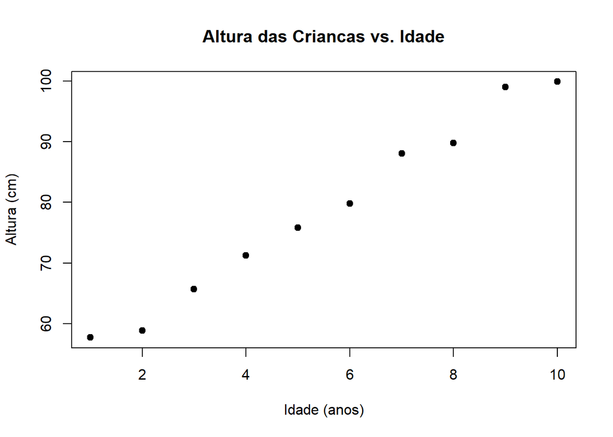

```r
# Gerar dados fictícios
set.seed(42)
idade <- 1:10
altura <- 50 + 5 * idade + rnorm(10, sd = 2)

# Criar um data frame
dados <- data.frame(idade = idade, altura = altura)

# Visualizar os dados
plot(dados$idade, dados$altura, main = "Altura das Criancas vs. Idade",
     xlab = "Idade (anos)", ylab = "Altura (cm)", pch = 19)
```

### 15.3.2 Cálculo dos Coeficientes de Regressão

Vamos ajustar um modelo de regressão linear simples aos dados e calcular os coeficientes de regressão.

```r
# Ajustar o modelo de regressão linear
modelo <- lm(altura ~ idade, data = dados)

# Resumo do modelo
summary(modelo)
```

```
##
## Call:
## lm(formula = altura ~ idade, data = dados)
##
## Residuals:
##    Min     1Q Median     3Q    Max
## -2.011 -1.411 -0.236  1.444  2.729
##
## Coefficients:
##             Estimate Std. Error t value Pr(>|t|)
## (Intercept)  50.7602     1.2033   42.18 1.10e-10 ***
## idade         5.0608     0.1939   26.10 4.99e-09 ***
## ---
## Signif. codes:  0 '***' 0.001 '**' 0.01 '*' 0.05 '.' 0.1 ' ' 1
##
## Residual standard error: 1.761 on 8 degrees of freedom
## Multiple R-squared:  0.9884, Adjusted R-squared:  0.9869
## F-statistic:   681 on 1 and 8 DF,  p-value: 4.993e-09
```

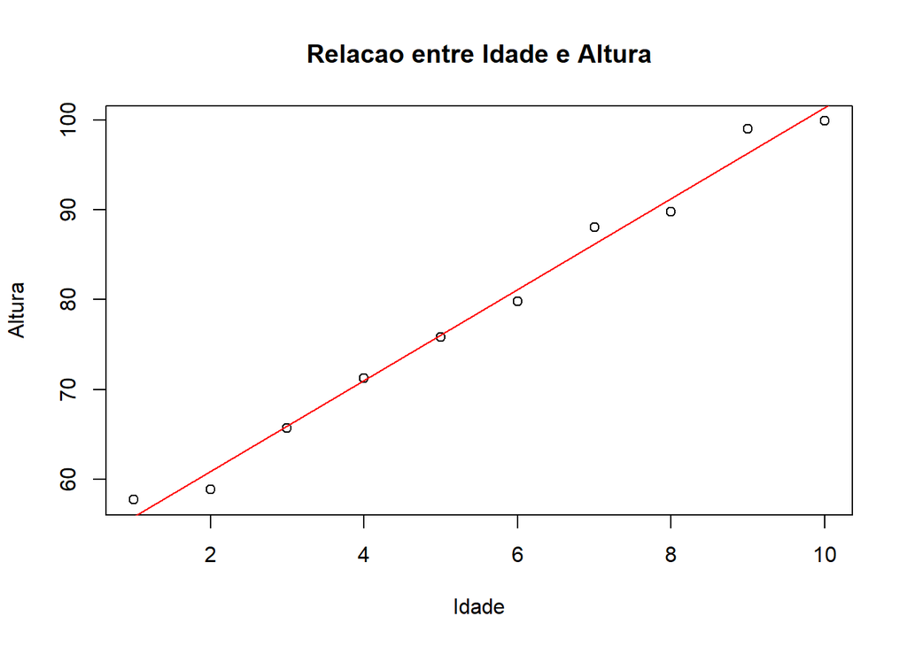

```r
# Criar gráfico de dispersão
plot(dados$idade, dados$altura,
     xlab = "Idade", ylab = "Altura",
     main = "Relacao entre Idade e Altura")

# Adicionar a linha de regressão ao gráfico
abline(modelo, col = "red")
```

### 15.3.3 Previsão de Novos Valores

Podemos usar o modelo ajustado para prever a altura para novas idades.

```r
# Prever altura para novas idades
novas_idades <- data.frame(idade = c(11, 12, 13))
previsoes <- predict(modelo, novas_idades)

# Mostrar previsões
previsoes
```

```
##        1        2        3
## 106.4290 111.4898 116.5505
```

## 15.4 Avaliação do Modelo de Regressão

### 15.4.1 Coeficiente de Determinação ($R^2$)

O coeficiente de determinação indica a proporção da variabilidade em $y$ que é explicada pelo modelo.

```r
# Coeficiente de determinação
r_squared <- summary(modelo)$r.squared
r_squared
```

```
## [1] 0.9883888
```

### 15.4.2 Análise de Resíduos

Verifique a adequação do modelo analisando os resíduos.

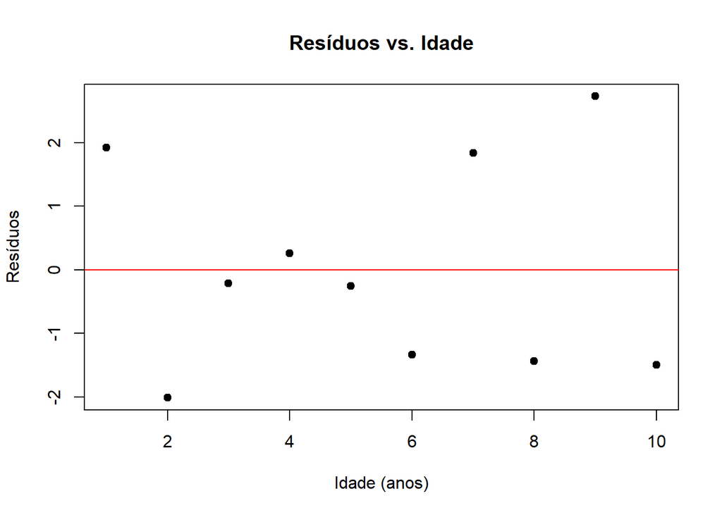

```r
# Resíduos do modelo
residuos <- residuals(modelo)

# Gráfico dos resíduos
plot(dados$idade, residuos, main = "Resíduos vs. Idade",
     xlab = "Idade (anos)", ylab = "Resíduos", pch = 19)
abline(h = 0, col = "red")
```

## 15.5 Limitações da Regressão Linear Simples

A regressão linear simples assume:

- **Linearidade**: A relação entre $x$ e $y$ deve ser linear.
- **Homoscedasticidade**: A variancia dos residuos deve ser constante.
- **Normalidade dos Resíduos**: Os resíduos devem ser normalmente distribuídos.

### 15.5.1 Consequências da Violação das Premissas

Se essas premissas não forem atendidas, os resultados da regressão podem ser inválidos e levar a inferências incorretas.

## 15.6 Regressão Linear Múltipla

Quando há mais de uma variável independente, usamos a regressão linear múltipla. O modelo é ajustado da seguinte forma:

$$y = \alpha + \beta_1 x_1 + \beta_2 x_2
+ \cdots + \beta_k x_k$$

Onde $x_1, x_2, \ldots, x_k$ são as variáveis independentes.

### 15.6.1 Interpretação dos Coeficientes

Cada coeficiente ($\beta_i$) representa a mudança em $y$ associada a uma unidade de mudança em $x_i$, mantendo as outras variáveis constantes.

# 16 GLM (ANOVA e Regressão) e Correlação de Pearson

## 16.1 Introdução

A análise de variância (ANOVA) e a regressão linear são ferramentas estatísticas complementares que ajudam a entender a relação entre variáveis categóricas e contínuas. Ambos os métodos são utilizados para prever variáveis dependentes com base em variáveis independentes, minimizando a distância entre o modelo e os dados observados. A correlação de Pearson, por outro lado, mede a força e direção da associação linear entre duas variáveis contínuas.

## 16.2 Modelo Linear Geral (GLM)

O Modelo Linear Geral (GLM) é a base da ANOVA e da regressão linear. Ele pode ser representado pela seguinte equação:

$$Y = \beta_0 + \beta_1X_1 + \beta_2X_2 + \ldots + \beta_pX_p + \epsilon$$

Onde: - $Y$ é a variável dependente. - $\beta_0$ é o intercepto do modelo. - $\beta_i$ são os coeficientes que quantificam a relação entre cada variável independente $X_i$ e a variável dependente $Y$. - $\epsilon$ representa o erro aleatório, que se supõe ter distribuição normal, média zero e variância constante.

## 16.3 Regressão Linear

A regressão linear é uma técnica estatística que visa modelar a relação entre uma variável dependente contínua e uma ou mais variáveis independentes. A regressão linear simples, com apenas uma variável independente, é representada pela equação:

$$Y = \beta_0 + \beta_1X + \epsilon$$

### 16.3.1 Interpretação dos Coeficientes

1. **Intercepto (**$\beta_0$): Valor de $Y$ quando $X = 0$. Representa a posição da linha de regressão no eixo $Y$.
2. **Coeficiente Angular (**$\beta_1$): Indica a mudança esperada em $Y$ para cada unidade adicional em $X$. Um coeficiente positivo indica uma relação direta, enquanto um negativo indica uma relação inversa.

### 16.3.2 Exemplo Prático

Vamos ilustrar a regressão linear simples com um exemplo em R:

```r
# Dados de exemplo
idade <- c(18, 22, 25, 30, 35)
salario <- c(2000, 2500, 3000, 4000, 5000)

# Modelo de regressão linear
modelo <- lm(salario ~ idade)
summary(modelo)
```

```
##
## Call:
## lm(formula = salario ~ idade)
##
## Residuals:
##       1       2       3       4       5
##  138.20  -80.90 -120.22  -19.10   82.02
##
## Coefficients:
##              Estimate Std. Error t value Pr(>|t|)
## (Intercept) -1374.157    250.771   -5.48 0.011952 *
## idade         179.775      9.401   19.12 0.000312 ***
## ---
## Signif. codes:  0 '***' 0.001 '**' 0.01 '*' 0.05 '.' 0.1 ' ' 1
##
## Residual standard error: 125.4 on 3 degrees of freedom
## Multiple R-squared:  0.9919, Adjusted R-squared:  0.9892
## F-statistic: 365.7 on 1 and 3 DF,  p-value: 0.0003122
```

Neste exemplo, `idade` é a variável independente e `salario` é a variável dependente. O resumo do modelo (`summary(modelo)`) fornece os coeficientes $\beta_0$ e $\beta_1$, além de métricas de ajuste como o valor-p e o coeficiente de determinação ($R^2$).

### 16.3.3 Coeficiente de Determinação ($R^2$)

O $R^2$ mede a proporção da variabilidade em $Y$ que é explicada pelas variáveis independentes. Varia entre 0 e 1, sendo 1 um ajuste perfeito. O $R^2$ ajustado corrige o $R^2$ para o número de preditores no modelo, penalizando modelos mais complexos que não melhoram significativamente a explicação da variabilidade.

## 16.4 ANOVA (Análise de Variância)

A ANOVA é usada para comparar as médias de três ou mais grupos, verificando se há diferenças significativas entre eles. O objetivo é determinar se as médias dos grupos são estatisticamente diferentes ou se as diferenças observadas podem ser explicadas pela variação aleatória.

### 16.4.1 Modelo ANOVA

A ANOVA de um fator (One-Way ANOVA) é representada pela seguinte fórmula:

$$Y_{ij} = \mu + \alpha_i + \epsilon_{ij}$$

Onde: - $Y_{ij}$ é a observação na $i$-ésima categoria e $j$-ésima amostra. - $\mu$ é a média geral. - $\alpha_i$ é o efeito do $i$-ésimo grupo. - $\epsilon_{ij}$ é o erro aleatório.

### 16.4.2 Teste F

O teste F na ANOVA compara a variabilidade entre grupos com a variabilidade dentro dos grupos. A estatística F é dada por:

$$F = \frac{SQA / gl_A}{SQE / gl_E}$$

Onde: - $SQA$ é a soma dos quadrados entre os grupos. - $SQE$ é a soma dos quadrados dentro dos grupos (erro). - $gl_A$ e $gl_E$ são os graus de liberdade correspondentes.

Se o valor de F calculado for maior que o valor crítico da distribuição F para um determinado nível de significância, rejeitamos a hipótese nula de que as médias dos grupos são iguais.

### 16.4.3 Exemplo Prático

```r
# Exemplo de ANOVA de um fator
grupo <- factor(c(rep("A", 5), rep("B", 5), rep("C", 5)))
peso <- c(5, 4, 6, 5, 5, 7, 8, 7, 9, 8, 6, 7, 6, 5, 6)

# Modelo ANOVA
modelo_anova <- aov(peso ~ grupo)
summary(modelo_anova)
```

```
##             Df Sum Sq Mean Sq F value   Pr(>F)
## grupo        2  20.13  10.067   17.77 0.000259 ***
## Residuals   12   6.80   0.567
## ---
## Signif. codes:  0 '***' 0.001 '**' 0.01 '*' 0.05 '.' 0.1 ' ' 1
```

Neste exemplo, `grupo` representa os diferentes tratamentos (A, B, C), e `peso` é a variável resposta. A ANOVA testa se há diferenças significativas entre os pesos médios dos grupos.

## 16.5 Correlação de Pearson

A correlação de Pearson mede a associação linear entre duas variáveis contínuas. O coeficiente de correlação de Pearson ($r$) é calculado como:

$$r = \frac{\sum (X_i - \bar{X})(Y_i - \bar{Y})}{\sqrt{\sum (X_i -
\bar{X})^2 \sum (Y_i - \bar{Y})^2}}$$

Onde: - $X_i$ e $Y_i$ são as observações das variáveis $X$ e $Y$. - $\bar{X}$ e $\bar{Y}$ são as médias de $X$ e $Y$.

### 16.5.1 Interpretação

- $r > 0$: Correlação positiva (quando $X$ aumenta, $Y$ tende a aumentar).
- $r < 0$: Correlação negativa (quando $X$ aumenta, $Y$ tende a diminuir).
- $r = 0$: Nenhuma correlação linear.

### 16.5.2 Exemplo Prático

```r
# Exemplo de correlação de Pearson
altura <- c(150, 160, 170, 180, 190)
peso <- c(50, 60, 70, 80, 90)

cor.test(altura, peso)
```

```
##
##  Pearson's product-moment correlation
##
## data:  altura and peso
## t = Inf, df = 3, p-value < 2.2e-16
## alternative hypothesis: true correlation is not equal to 0
## 95 percent confidence interval:
##  1 1
## sample estimates:
## cor
##   1
```

O resultado inclui o coeficiente de correlação e o valor-p associado ao teste de hipótese de que a correlação é igual a zero. Isso permite avaliar se a relação linear entre altura e peso é estatisticamente significativa.

## 16.6 Considerações sobre a Modelagem

Ao construir modelos de regressão ou ANOVA, é essencial verificar os pressupostos do modelo, como a normalidade dos resíduos e a homogeneidade das variâncias. Além disso, é importante usar o modelo mais simples possível para explicar os dados, de acordo com o princípio da parcimônia.

### 16.6.1 Verificação dos Resíduos

Para verificar a adequação do modelo, é fundamental analisar os resíduos:

1. **Gráfico de Resíduos vs. Ajustados**: Verifica a homogeneidade da variância.
2. **Histograma dos Resíduos**: Verifica a normalidade dos resíduos.
3. **Gráfico Q-Q**: Compara os resíduos com uma distribuição normal.

Exemplo de código para verificar resíduos em R:

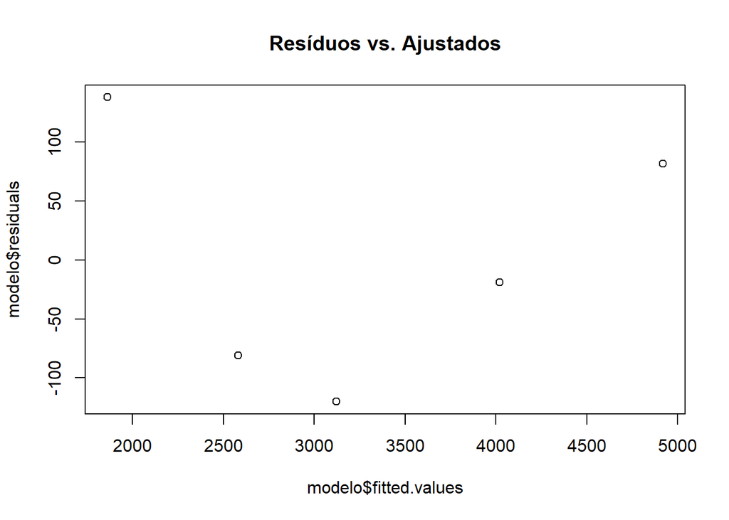

```r
# Verificação dos resíduos
plot(modelo$residuals ~ modelo$fitted.values, main = "Resíduos vs. Ajustados")
```

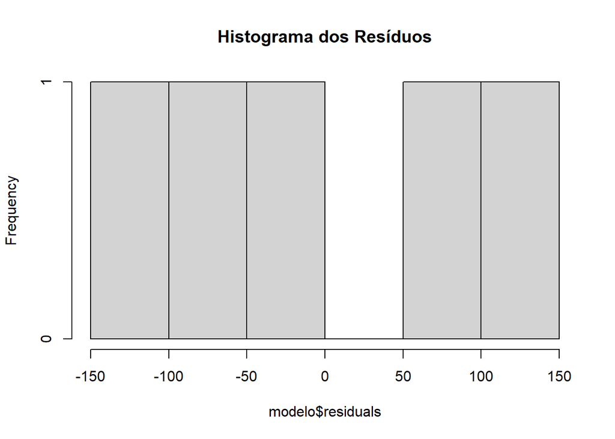

```r
hist(modelo$residuals, main = "Histograma dos Resíduos")
```

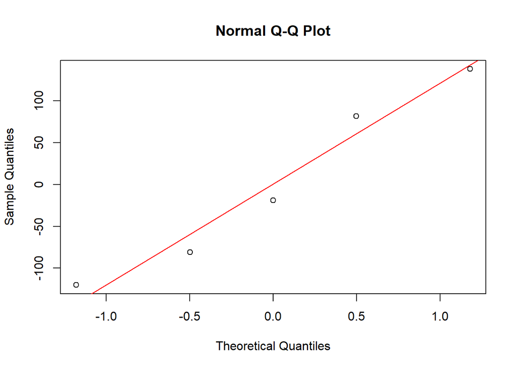

```r
qqnorm(modelo$residuals)
qqline(modelo$residuals, col = "red")
```

Esses gráficos ajudam a garantir que os pressupostos do modelo foram atendidos e que as inferências realizadas são válidas.

# 17 Linearização de Dados, Correlação Parcial e Correlação de Spearman

## 17.1 Linearização de Dados

Em muitos casos, a relação entre variáveis não é linear, o que pode dificultar a modelagem e a análise dos dados. Para lidar com isso, podemos aplicar transformações que linearizam essa relação, facilitando o uso de métodos lineares como a regressão linear.

### 17.1.1 Transformações Comuns

1. **Transformação Logarítmica**: Usada quando os dados têm uma distribuição exponencial ou geométrica. A transformação é dada por:

   $$Y' = \log(Y)$$

   Esta transformação é útil para modelar relações multiplicativas ou reduzir a variância de dados positivos com grande amplitude.
2. **Transformação Recíproca**: Indicada para relações inversas. A transformação é dada por:

   $$Y' = \frac{1}{Y}$$

   É útil para dados que crescem rapidamente e se estabilizam ou para modelar relações de tipo `y = a + \frac{b}{x}`.
3. **Transformação de Raiz Quadrada**: Indicada para estabilizar variâncias quando os dados são contagens ou seguem uma distribuição de Poisson. A transformação é dada por:

   $$Y' = \sqrt{Y}$$

   Reduz a assimetria dos dados, especialmente para variáveis que assumem valores inteiros não negativos.
4. **Transformação de Box-Cox**: Uma técnica mais abrangente que encontra a melhor transformação para os dados através de um parâmetro $\lambda$.

   $$Y' = \frac{Y^{\lambda} - 1}{\lambda}, \quad \lambda \neq 0$$

   Para $\lambda = 0$, a transformação é equivalente à transformação logarítmica.

### 17.1.2 Exemplo Prático

Vamos usar um exemplo em R para aplicar a transformação logarítmica:

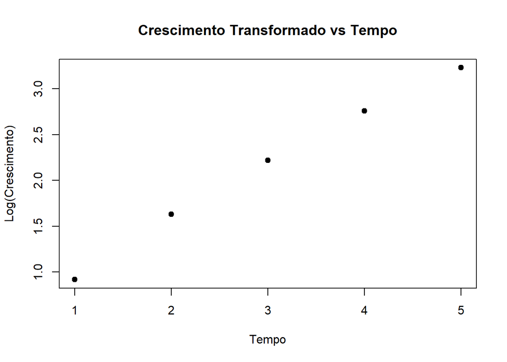

```r
# Dados de exemplo
tempo <- c(1, 2, 3, 4, 5)
crescimento <- c(2.5, 5.1, 9.2, 15.8, 25.3)

# Transformação logarítmica
log_crescimento <- log(crescimento)

# Plotagem dos dados transformados
plot(tempo, log_crescimento, main = "Crescimento Transformado vs Tempo", xlab = "Tempo", ylab = "Log(Crescimento)", pch = 19)
```

Neste exemplo, aplicamos a transformação logarítmica aos dados de crescimento. A relação linearizada facilita a modelagem com métodos lineares.

## 17.2 Correlação Parcial

A correlação parcial mede a força e a direção da relação linear entre duas variáveis, controlando o efeito de uma ou mais variáveis adicionais. É uma extensão da correlação de Pearson, considerando o impacto de outras variáveis na relação entre duas variáveis de interesse.

### 17.2.1 Cálculo da Correlação Parcial

Seja $r_{XY}$ a correlação entre $X$ e $Y$, $r_{XZ}$ a correlação entre $X$ e $Z$, e $r_{YZ}$ a correlação entre $Y$ e $Z$. A correlação parcial entre $X$ e $Y$, controlando $Z$, é dada por:

$$r_{XY|Z} = \frac{r_{XY} - r_{XZ} \cdot r_{YZ}}{\sqrt{(1 - r_{XZ}^2)
\cdot (1 - r_{YZ}^2)}}$$

Este coeficiente remove o efeito de $Z$ na relação entre $X$ e $Y$, permitindo avaliar a relação direta entre essas duas variáveis.

### 17.2.2 Exemplo Prático

Vamos calcular a correlação parcial entre três variáveis fictícias:

```r
# Pacote necessário para correlação parcial
#install.packages("ppcor")
library(ppcor)
# Dados de exemplo
x <- c(10, 20, 30, 40, 50)
y <- c(5, 15, 25, 35, 45)
z <- c(2, 4, 6, 8, 10)

# Correlação parcial
resultado <- pcor.test(x, y, z)
resultado
```

| estimate | p.value | statistic | n | gp | Method |
| --- | --- | --- | --- | --- | --- |
| -1 | NaN | NaN | 5 | 1 | pearson |

## 17.3 Correlação de Spearman

A correlação de Spearman é uma medida de associação entre duas variáveis baseada nas classificações (ranks) das observações. Ela é usada quando os dados não atendem aos pressupostos de normalidade ou quando a relação entre as variáveis não é linear, mas ainda é monotônica (sempre crescente ou decrescente).

### 17.3.1 Coeficiente de Spearman

O coeficiente de correlação de Spearman ($\rho$) é calculado como:

$$\rho = 1 - \frac{6 \sum d_i^2}{n(n^2 - 1)}$$

Onde: - $d_i$ é a diferença entre os ranks das duas variáveis para a $i$-ésima observação. - $n$ é o número de observações.

### 17.3.2 Interpretação

- $\rho > 0$: Indica que, à medida que uma variável aumenta, a outra tende a aumentar também (relação positiva).
- $\rho < 0$: Indica que, à medida que uma variável aumenta, a outra tende a diminuir (relação negativa).
- $\rho = 0$: Indica que não há relação monotônica entre as variáveis.

### 17.3.3 Exemplo Prático

Vamos calcular a correlação de Spearman para um conjunto de dados fictício em R:

```r
# Dados de exemplo
altura <- c(160, 165, 170, 175, 180)
peso <- c(60, 65, 70, 75, 80)

# Correlação de Spearman
cor.test(altura, peso, method = "spearman")
```

```
##
##  Spearman's rank correlation rho
##
## data:  altura and peso
## S = 4.4409e-15, p-value = 0.01667
## alternative hypothesis: true rho is not equal to 0
## sample estimates:
## rho
##   1
```

O resultado inclui o coeficiente $\rho$ e o valor-p, permitindo avaliar se a relação entre altura e peso é monotônica e significativa.

### 17.3.4 Quando Usar a Correlação de Spearman?

A correlação de Spearman é indicada quando: 1. Os dados não são normalmente distribuídos. 2. A relação entre as variáveis é monotônica, mas não linear. 3. Há presença de outliers que podem distorcer a correlação de Pearson.

# 18 GLM com Preditores Discretos e Contínuos

## 18.1 Modelo Linear Generalizado (GLM)

Os Modelos Lineares Generalizados (GLM) são uma extensão dos modelos lineares clássicos, permitindo modelar variáveis dependentes que não seguem uma distribuição normal, como variáveis binárias, contagens ou proporções. Um GLM consiste em três componentes principais:

1. **Função de Ligação (Link Function)**: Relaciona a média da variável resposta ao preditor linear. Exemplo: `logit` para regressão logística, `log` para Poisson.
2. **Distribuição da Família Exponencial**: Define a distribuição da variável resposta. Exemplo: binomial, Poisson, normal.
3. **Preditor Linear**: Combinação linear dos preditores (variáveis explicativas). Exemplo: $\beta_0 + \beta_1X_1 + \beta_2X_2$.

## 18.2 Preditores Discretos e Contínuos

### 18.2.1 Preditores Contínuos

Preditores contínuos são variáveis numéricas que podem assumir qualquer valor dentro de um intervalo. Exemplo: altura, peso, idade.

#### 18.2.1.1 Exemplo de Preditor Contínuo

Considere um modelo que relaciona o número de visitas ao hospital (variável dependente) com a idade do paciente (preditor contínuo) usando uma regressão de Poisson:

```r
# Dados de exemplo
idade <- c(20, 25, 30, 35, 40, 45, 50, 55, 60, 65)
visitas <- c(2, 3, 4, 3, 5, 6, 4, 5, 7, 8)

# Modelo de Poisson com preditor contínuo
modelo_poisson <- glm(visitas ~ idade, family = poisson(link = "log"))
summary(modelo_poisson)
```

```
##
## Call:
## glm(formula = visitas ~ idade, family = poisson(link = "log"))
##
## Coefficients:
##             Estimate Std. Error z value Pr(>|z|)
## (Intercept)  0.46728    0.51922   0.900   0.3681
## idade        0.02403    0.01053   2.283   0.0224 *
## ---
## Signif. codes:  0 '***' 0.001 '**' 0.01 '*' 0.05 '.' 0.1 ' ' 1
##
## (Dispersion parameter for poisson family taken to be 1)
##
##     Null deviance: 6.8694  on 9  degrees of freedom
## Residual deviance: 1.4669  on 8  degrees of freedom
## AIC: 38.96
##
## Number of Fisher Scoring iterations: 4
```

Neste exemplo, a variável `idade` é um preditor contínuo que influencia o número de `visitas` ao hospital.

### 18.2.2 Preditores Discretos

Preditores discretos são variáveis categóricas que representam diferentes grupos ou níveis. Exemplo: gênero (masculino/feminino), tipo de tratamento (A/B/C).

#### 18.2.2.1 Exemplo de Preditor Discreto

Considere um modelo que relaciona o sucesso de um tratamento (variável dependente binária) com o tipo de tratamento recebido (preditor discreto) usando uma regressão logística:

```r
# Dados de exemplo
tratamento <- factor(c("A", "B", "A", "C", "B", "C", "A", "C", "B", "A"))
sucesso <- c(1, 0, 1, 0, 1, 1, 0, 0, 1, 1)

# Modelo de regressão logística com preditor discreto
modelo_logistico <- glm(sucesso ~ tratamento, family = binomial(link = "logit"))
summary(modelo_logistico)
```

```
##
## Call:
## glm(formula = sucesso ~ tratamento, family = binomial(link = "logit"))
##
## Coefficients:
##             Estimate Std. Error z value Pr(>|z|)
## (Intercept)   1.0986     1.1547   0.951    0.341
## tratamentoB  -0.4055     1.6832  -0.241    0.810
## tratamentoC  -1.7918     1.6832  -1.064    0.287
##
## (Dispersion parameter for binomial family taken to be 1)
##
##     Null deviance: 13.460  on 9  degrees of freedom
## Residual deviance: 12.137  on 7  degrees of freedom
## AIC: 18.137
##
## Number of Fisher Scoring iterations: 4
```

## 18.3 GLM com Preditores Mistos

Os GLMs permitem combinar preditores discretos e contínuos no mesmo modelo, possibilitando a análise do impacto simultâneo de variáveis categóricas e numéricas na variável resposta.

### 18.3.1 Exemplo Prático

Vamos considerar um modelo que avalia o impacto da idade (contínua) e do tipo de tratamento (discreta) no número de visitas ao hospital (modelo de contagem).

```r
# Dados de exemplo
tratamento <- factor(c("A", "B", "A", "C", "B", "C", "A", "C", "B", "A"))
idade <- c(20, 25, 30, 35, 40, 45, 50, 55, 60, 65)
visitas <- c(2, 3, 4, 3, 5, 6, 4, 5, 7, 8)

# Modelo de Poisson com preditores mistos
modelo_misto <- glm(visitas ~ idade + tratamento, family = poisson(link = "log"))
summary(modelo_misto)
```

```
##
## Call:
## glm(formula = visitas ~ idade + tratamento, family = poisson(link = "log"))
##
## Coefficients:
##             Estimate Std. Error z value Pr(>|z|)
## (Intercept)  0.41715    0.56396   0.740    0.459
## idade        0.02419    0.01056   2.291    0.022 *
## tratamentoB  0.12377    0.35016   0.353    0.724
## tratamentoC  0.01514    0.35692   0.042    0.966
## ---
## Signif. codes:  0 '***' 0.001 '**' 0.01 '*' 0.05 '.' 0.1 ' ' 1
##
## (Dispersion parameter for poisson family taken to be 1)
##
##     Null deviance: 6.8694  on 9  degrees of freedom
## Residual deviance: 1.3271  on 6  degrees of freedom
## AIC: 42.82
##
## Number of Fisher Scoring iterations: 4
```

### 18.3.2 Interpretação do Modelo

No modelo misto, cada coeficiente representa a mudança esperada na variável dependente em resposta a uma mudança de uma unidade na variável contínua (idade) ou à mudança de um nível de referência na variável discreta (tratamento). Os principais pontos a serem observados incluem:

- **Coeficiente da Idade**: Indica o impacto da idade no número de visitas.
- **Coeficientes dos Tratamentos**: Comparação do efeito dos tratamentos B e C em relação ao tratamento A (nível de referência).

## 18.4 Interação entre Preditores

Os GLMs também permitem a inclusão de termos de interação entre preditores. A interação avalia como o efeito de um preditor varia de acordo com o nível de outro preditor.

### 18.4.1 Exemplo de Interação

Considere a interação entre idade e tipo de tratamento no impacto das visitas ao hospital:

```r
# Modelo com interação entre idade e tratamento
modelo_interacao <- glm(visitas ~ idade * tratamento, family = poisson(link = "log"))
summary(modelo_interacao)
```

```
##
## Call:
## glm(formula = visitas ~ idade * tratamento, family = poisson(link = "log"))
##
## Coefficients:
##                    Estimate Std. Error z value Pr(>|z|)
## (Intercept)        0.350762   0.729541   0.481   0.6307
## idade              0.025557   0.014122   1.810   0.0703 .
## tratamentoB        0.260270   1.146120   0.227   0.8204
## tratamentoC        0.202436   1.722627   0.118   0.9065
## idade:tratamentoB -0.002872   0.023073  -0.124   0.9010
## idade:tratamentoC -0.003963   0.036000  -0.110   0.9123
## ---
## Signif. codes:  0 '***' 0.001 '**' 0.01 '*' 0.05 '.' 0.1 ' ' 1
##
## (Dispersion parameter for poisson family taken to be 1)
##
##     Null deviance: 6.8694  on 9  degrees of freedom
## Residual deviance: 1.3048  on 4  degrees of freedom
## AIC: 46.798
##
## Number of Fisher Scoring iterations: 4
```

### 18.4.2 Interpretação da Interação

- O coeficiente da interação `idade:tratamentoB` indica como o efeito da idade muda quando o tratamento B é aplicado, comparado ao tratamento A.
- Da mesma forma, `idade:tratamentoC` indica a mudança no efeito da idade para o tratamento C em comparação ao A.

Esses termos ajudam a entender se a resposta ao tratamento varia conforme a idade, fornecendo uma visão mais completa sobre os efeitos combinados das variáveis.

## 18.5 Verificação de Ajuste do Modelo

Após ajustar um GLM, é crucial verificar se o modelo se ajusta bem aos dados e se atende aos pressupostos do GLM. Algumas verificações incluem:

1. **Resíduos**: Analisar a distribuição dos resíduos para identificar padrões não capturados pelo modelo.
2. **Gráficos de Resíduos vs Ajustados**: Devem mostrar uma distribuição aleatória dos resíduos.
3. **Teste de Deviance**: Compara o modelo ajustado com o modelo nulo para verificar a significância do modelo.

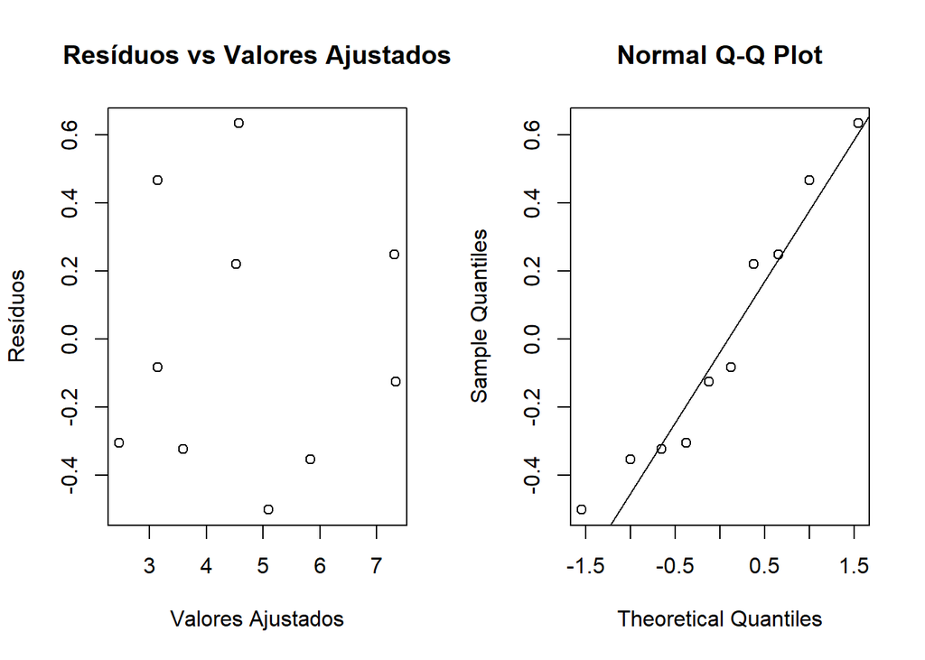

```r
# Análise dos resíduos
par(mfrow = c(1, 2))  # Dividir a área de gráficos em 1 linha e 2 colunas
plot(modelo_misto$fitted.values, resid(modelo_misto),
     main = "Resíduos vs Valores Ajustados",
     xlab = "Valores Ajustados", ylab = "Resíduos")

# Gráfico Q-Q dos resíduos
qqnorm(resid(modelo_misto))
qqline(resid(modelo_misto))
```

Esses gráficos ajudam a identificar a qualidade do ajuste do modelo e possíveis violações dos pressupostos do GLM.

# 19 Regressão Logística

## 19.1 Introdução

A regressão logística é uma técnica estatística utilizada para modelar a probabilidade de um evento ocorrer, considerando uma ou mais variáveis independentes. É amplamente usada quando a variável resposta é categórica, especialmente binária (com dois resultados possíveis: 0 e 1).

## 19.2 Conceito

A regressão logística usa a função logística para transformar uma combinação linear das variáveis preditoras em uma probabilidade, variando de 0 a 1. A função logística é dada por:

$$P(Y = 1 | X) = \frac{1}{1 + e^{-(\beta_0 + \beta_1 X_1 + \beta_2 X_2 +
\ldots + \beta_k X_k)}}$$

onde:

- $P(Y = 1 | X)$ é a probabilidade de o evento ocorrer (ou seja, a variável dependente ser igual a 1).
- $\beta_0$ é o intercepto.
- $\beta_1, \beta_2, \ldots, \beta_k$ são os coeficientes das variáveis independentes $X_1, X_2, \ldots, X_k$.

## 19.3 Exemplo Prático

Vamos ajustar um modelo de regressão logística para prever a presença de diabetes (`1` = diabetes, `0` = sem diabetes) com base em variáveis como idade e nível de glicose.

### 19.3.1 Conjunto de Dados

```r
# Dados de exemplo
idade <- c(25, 34, 28, 52, 46, 38, 50, 40, 45, 56, 30, 29, 60, 35, 44)
glicose <- c(85, 120, 88, 150, 140, 110, 145, 130, 135, 160, 90, 100, 170, 115, 125)
diabetes <- c(0, 1, 0, 1, 1, 0, 1, 0, 1, 1, 0, 0, 1, 0, 1)

# Criar um dataframe
dados <- data.frame(idade, glicose, diabetes)
```

### 19.3.2 Ajuste do Modelo de Regressão Logística

Para ajustar o modelo de regressão logística, usamos a função `glm()` com a família `binomial` e o link `logit`.

```r
# Ajustar o modelo de regressão logística
modelo_logistico <- glm(diabetes ~ idade + glicose, family = binomial, data = dados)

# Resumo do modelo
summary(modelo_logistico)
```

```
##
## Call:
## glm(formula = diabetes ~ idade + glicose, family = binomial,
##     data = dados)
##
## Coefficients:
##              Estimate Std. Error z value Pr(>|z|)
## (Intercept) -20.49895   12.40702  -1.652   0.0985 .
## idade         0.06651    0.31414   0.212   0.8323
## glicose       0.14651    0.15693   0.934   0.3505
## ---
## Signif. codes:  0 '***' 0.001 '**' 0.01 '*' 0.05 '.' 0.1 ' ' 1
##
## (Dispersion parameter for binomial family taken to be 1)
##
##     Null deviance: 20.7277  on 14  degrees of freedom
## Residual deviance:  7.0262  on 12  degrees of freedom
## AIC: 13.026
##
## Number of Fisher Scoring iterations: 7
```

### 19.3.3 Interpretação dos Coeficientes

Os coeficientes da regressão logística representam a mudança nas log-odds de ter diabetes para cada unidade de aumento nas variáveis independentes, mantendo as outras constantes. Para interpretar as odds, usamos a função exponencial:

```r
# Calcular a exponencial dos coeficientes
exp(coef(modelo_logistico))
```

```
##  (Intercept)        idade      glicose
## 1.251465e-09 1.068769e+00 1.157783e+00
```

- Um coeficiente positivo indica que a variável aumenta as chances de ter diabetes.
- Um coeficiente negativo indica que a variável reduz as chances de ter diabetes.

### 19.3.4 Predição de Probabilidades

Podemos usar o modelo ajustado para prever a probabilidade de um novo paciente ter diabetes.

```r
# Dados do novo paciente
novo_paciente <- data.frame(idade = 50, glicose = 140)

# Predição de probabilidade
predicao <- predict(modelo_logistico, novo_paciente, type = "response")
predicao  # Probabilidade de ter diabetes
```

```
##         1
## 0.9656901
```

Neste exemplo, a função `predict` com `type = "response"` retorna a probabilidade de um paciente de 50 anos com glicose 140 ter diabetes.

## 19.4 Avaliação do Modelo

### 19.4.1 Matriz de Confusão

A matriz de confusão mostra o desempenho do modelo em termos de previsões corretas e incorretas.

```r
# Definir ponto de corte (threshold)
threshold <- 0.5
predicao_binaria <- ifelse(predict(modelo_logistico, type = "response") > threshold, 1, 0)

# Criar a matriz de confusão
tabela_confusao <- table(Predito = predicao_binaria, Real = dados$diabetes)
tabela_confusao
```

```
##        Real
## Predito 0 1
##       0 6 1
##       1 1 7
```

### 19.4.2 Cálculo da Acurácia, Sensibilidade e Especificidade

- **Acurácia**: Proporção de previsões corretas.
- **Sensibilidade**: Proporção de verdadeiros positivos.
- **Especificidade**: Proporção de verdadeiros negativos.

```r
# Calcular Acurácia
acuracia <- sum(diag(tabela_confusao)) / sum(tabela_confusao)
acuracia
```

```
## [1] 0.8666667
```

```r
# Calcular Sensibilidade
sensibilidade <- tabela_confusao[2, 2] / sum(tabela_confusao[, 2])
sensibilidade
```

```
## [1] 0.875
```

```r
# Calcular Especificidade
especificidade <- tabela_confusao[1, 1] / sum(tabela_confusao[, 1])
especificidade
```

```
## [1] 0.8571429
```

### 19.4.3 Curva ROC e AUC

A curva ROC é uma representação gráfica da sensibilidade contra o complemento da especificidade (1 - especificidade), e a área sob a curva (AUC) mede o desempenho global do modelo.

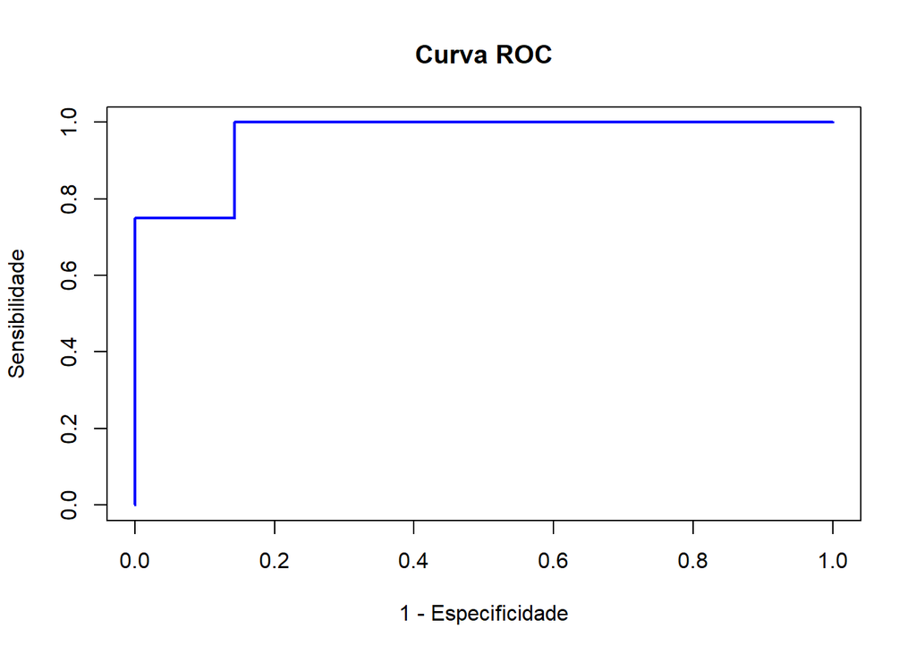

```r
# Criar valores de sensibilidade e especificidade para diferentes thresholds
thresholds <- seq(0, 1, length.out = 100)
sensibilidade_vals <- numeric(length(thresholds))
especificidade_vals <- numeric(length(thresholds))

for (i in 1:length(thresholds)) {
  predicao_temp <- ifelse(predict(modelo_logistico, type = "response") > thresholds[i], 1, 0)
  tabela_temp <- table(Predito = predicao_temp, Real = dados$diabetes)

  # Inicializar com zero para evitar índices fora dos limites
  sensibilidade <- 0
  especificidade <- 0

  # Verificar se há valores para calcular sensibilidade e especificidade
  if ("1" %in% rownames(tabela_temp) && "1" %in% colnames(tabela_temp)) {
    sensibilidade <- tabela_temp["1", "1"] / sum(tabela_temp[, "1"])
  }
  if ("0" %in% rownames(tabela_temp) && "0" %in% colnames(tabela_temp)) {
    especificidade <- tabela_temp["0", "0"] / sum(tabela_temp[, "0"])
  }

  sensibilidade_vals[i] <- sensibilidade
  especificidade_vals[i] <- especificidade
}

# Plotar a curva ROC
plot(1 - especificidade_vals, sensibilidade_vals, type = "l", col = "blue", lwd = 2,
     xlab = "1 - Especificidade", ylab = "Sensibilidade", main = "Curva ROC")
```

```r
# Calcular AUC
auc <- sum(diff(1 - especificidade_vals) * (sensibilidade_vals[-1] + sensibilidade_vals[-length(sensibilidade_vals)]) / 2)
auc
```

```
## [1] -0.9642857
```

# 20 Teste Qui-Quadrado para Contagens

Nesta aula, foi explorado o uso do teste Qui-Quadrado para verificar a associação entre variáveis categóricas em tabelas de contingência. Ele é particularmente útil para identificar se a distribuição observada difere da distribuição esperada sob a hipótese de independência.

## 20.1 Revisão do Teste Qui-Quadrado

O teste Qui-Quadrado compara as frequências observadas com as frequências esperadas em uma tabela de contingência. As hipóteses do teste são:

- **Hipótese Nula (H₀):** Não há associação entre as variáveis (elas são independentes).
- **Hipótese Alternativa (H₁):** Há uma associação entre as variáveis (elas não são independentes).

## 20.2 Cálculo do Teste Qui-Quadrado

O valor do teste Qui-Quadrado é calculado pela fórmula:

$$\chi^2 = \sum \frac{(O_i - E_i)^2}{E_i}$$

Onde: - $O_i$ são as frequências observadas. - $E_i$ são as frequências esperadas.

O valor $\chi^2$ é então comparado com a distribuição Qui-Quadrado com graus de liberdade (GL) dados por:

$$GL = (número \, de \, linhas - 1) \times (número \, de \, colunas - 1)$$

## 20.3 Exemplo Prático

Suponha que temos uma tabela de contingência com as seguintes frequências observadas:

|  | Produto A | Produto B |
| --- | --- | --- |
| Masculino | 50 | 30 |
| Feminino | 30 | 40 |

Desejamos saber se há uma associação significativa entre o gênero e a preferência pelo produto.

```r
# Dados observados
dados <- matrix(c(50, 30, 30, 40), nrow = 2, byrow = TRUE)
colnames(dados) <- c("Produto A", "Produto B")
rownames(dados) <- c("Masculino", "Feminino")

# Teste Qui-Quadrado
resultado_qui <- chisq.test(dados)

# Resultados
resultado_qui
```

```
##
##  Pearson's Chi-squared test with Yates' continuity correction
##
## data:  dados
## X-squared = 5.0253, df = 1, p-value = 0.02498
```

## 20.4 Interpretação dos Resultados

Se o valor-p do teste for menor que o nível de significância (por exemplo, 0,05), rejeitamos a hipótese nula e concluímos que há uma associação significativa entre o gênero e a preferência pelo produto.

## 20.5 Limitações do Teste Qui-Quadrado

1. **Frequências Esperadas Baixas:** O teste Qui-Quadrado não é apropriado quando as frequências esperadas em qualquer célula são menores que 5.
2. **Tabelas Grandes:** Pode ser difícil interpretar resultados de tabelas com muitas categorias.

# 21 Teste Qui-Quadrado para Contagens Não Paramétrico e Teste Exato de Fisher

Esta aula se concentrou na aplicação do Teste Qui-Quadrado em situações onde as premissas padrão não são atendidas, além de explorar o Teste Exato de Fisher como alternativa para tabelas pequenas.

## 21.1 Revisão do Teste Qui-Quadrado Não Paramétrico

O Teste Qui-Quadrado é geralmente utilizado quando as frequências esperadas são maiores que 5 em cada célula da tabela de contingência. Caso contrário, a precisão do teste diminui.

## 21.2 Teste Exato de Fisher

O Teste Exato de Fisher é usado como alternativa ao Teste Qui-Quadrado em tabelas de 2x2, especialmente quando as frequências esperadas são pequenas. Ele calcula o valor-p exato, sendo ideal para amostras pequenas.

### 21.2.1 Hipóteses do Teste Exato de Fisher

- **Hipótese Nula (H₀):** Não há associação entre as variáveis (elas são independentes).
- **Hipótese Alternativa (H₁):** Há uma associação entre as variáveis (elas não são independentes).

## 21.3 Exemplo Prático: Teste Exato de Fisher

Vamos considerar o seguinte exemplo para entender a aplicação do Teste Exato de Fisher. Suponha que queremos investigar a associação entre gênero e preferência por um produto, mas temos um tamanho amostral pequeno:

|  | Produto A | Produto B |
| --- | --- | --- |
| Masculino | 3 | 1 |
| Feminino | 2 | 4 |

```r
# Dados para o Teste Exato de Fisher
dados_fisher <- matrix(c(3, 1, 2, 4), nrow = 2, byrow = TRUE)
colnames(dados_fisher) <- c("Produto A", "Produto B")
rownames(dados_fisher) <- c("Masculino", "Feminino")

# Realizar o Teste Exato de Fisher
resultado_fisher <- fisher.test(dados_fisher)

# Resultados
resultado_fisher
```

```
##
##  Fisher's Exact Test for Count Data
##
## data:  dados_fisher
## p-value = 0.5238
## alternative hypothesis: true odds ratio is not equal to 1
## 95 percent confidence interval:
##    0.218046 390.562917
## sample estimates:
## odds ratio
##   4.918388
```

## 21.4 Interpretação dos Resultados

Assim como no Qui-Quadrado, se o valor-p for menor que 0,05, rejeitamos a hipótese nula, indicando uma associação significativa entre as variáveis.

## 21.5 Comparação entre Teste Qui-Quadrado e Teste Exato de Fisher

| Critério | Teste Qui-Quadrado | Teste Exato de Fisher |
| --- | --- | --- |
| **Aplicabilidade** | Grandes amostras, $E_i > 5$ | Pequenas amostras, $E_i < 5$ |
| **Cálculo do Valor-P** | Aproximado | Exato |
| **Flexibilidade** | Tabelas maiores que 2x2 | Principalmente tabelas 2x2 |
| **Robustez** | Sensível a pequenas amostras | Robusto para pequenas amostras |

## 21.6 Teste Exato de Fisher com Simulação

Para tabelas maiores que 2x2, o Teste Exato de Fisher pode ser aplicado usando simulações para calcular o valor-p. Isso é feito definindo o argumento `simulate.p.value = TRUE`:

```r
# Tabela maior que 2x2
dados_maiores <- matrix(c(1, 1, 1, 2, 2, 2), nrow = 2, byrow = TRUE)
colnames(dados_maiores) <- c("Categoria 1", "Categoria 2", "Categoria 3")
rownames(dados_maiores) <- c("Grupo 1", "Grupo 2")

# Teste Exato de Fisher com simulação
resultado_fisher_maior <- fisher.test(dados_maiores, simulate.p.value = TRUE)

# Resultados
resultado_fisher_maior
```

```
##
##  Fisher's Exact Test for Count Data with simulated p-value (based on
##  2000 replicates)
##
## data:  dados_maiores
## p-value = 1
## alternative hypothesis: two.sided
```

# 22 Informação de Fisher e Informação Mútua de Shannon

Nesta aula, exploramos os conceitos de Informação de Fisher e Informação Mútua de Shannon, fundamentais para a Teoria da Informação e para a análise de incertezas e previsibilidade de variáveis em diferentes contextos.

## 22.1 Informação de Fisher

A Informação de Fisher mede o quanto uma variável observável carrega de informação sobre um parâmetro desconhecido. Ela é usada principalmente em modelos estatísticos para avaliar a precisão com que um parâmetro pode ser estimado.

### 22.1.1 Fórmula da Informação de Fisher

A informação de Fisher é definida pela segunda derivada negativa do logaritmo da função de verossimilhança, $L(\theta)$, em relação ao parâmetro $\theta$:

$$I(\theta) = - \mathbb{E} \left[ \frac{\partial^2 \ln L(\theta)}{\partial
\theta^2} \right]$$

Onde: - $I(\theta)$ é a Informação de Fisher. - $L(\theta)$ é a função de verossimilhança.

A matriz de Informação de Fisher é utilizada para estimar a variância de estimadores de máxima verossimilhança.

### 22.1.2 Exemplo Prático

Para uma variável normal com média $\mu$ e variância $\sigma^2$, a informação de Fisher para o parâmetro $\mu$ é:

$$I(\mu) = \frac{1}{\sigma^2}$$

## 22.2 Informação Mútua de Shannon

A Informação Mútua mede a redução de incerteza sobre uma variável $X$ ao conhecer uma outra variável $Y$. Ela é uma medida de dependência entre variáveis e é baseada no conceito de entropia.

### 22.2.1 Fórmula da Informação Mútua

A Informação Mútua é dada por:

$$I(X; Y) = \sum_{x \in X} \sum_{y \in Y} p(x, y) \log \left( \frac{p(x,
y)}{p(x)p(y)} \right)$$

Onde: - $p(x, y)$ é a probabilidade conjunta de $X$ e $Y$. - $p(x)$ e $p(y)$ são as probabilidades marginais de $X$ e $Y$.

### 22.2.2 Exemplo Prático

Para calcular a informação mútua entre duas variáveis categóricas no R, podemos usar tabelas de contingência.

```r
# Exemplo simples de cálculo de informação mútua
tabela <- matrix(c(10, 20, 30, 40), nrow = 2, byrow = TRUE)
colnames(tabela) <- c("Variável X1", "Variável X2")
rownames(tabela) <- c("Variável Y1", "Variável Y2")

# Probabilidade conjunta
p_conjunta <- tabela / sum(tabela)

# Probabilidade marginal
p_marginal_x <- colSums(p_conjunta)
p_marginal_y <- rowSums(p_conjunta)

# Informação Mútua
info_mutua <- 0
for (i in 1:nrow(tabela)) {
  for (j in 1:ncol(tabela)) {
    if (p_conjunta[i, j] > 0) {
      info_mutua <- info_mutua + p_conjunta[i, j] * log(p_conjunta[i, j] / (p_marginal_x[j] * p_marginal_y[i]))
    }
  }
}

info_mutua
```

```
## Variável X1
## 0.004021743
```

# 23 Árvores de Decisão, Random Forest e Logit Multinomial em Dados Bancários

Nesta aula, discutimos o uso de Árvores de Decisão, Random Forest e Logit Multinomial para analisar dados bancários, focando na classificação de clientes e previsões de comportamento.

## 23.1 Árvores de Decisão

Árvores de decisão são modelos de classificação e regressão que dividem os dados em segmentos homogêneos baseados em características explicativas. Cada nó na árvore representa uma decisão baseada em um critério de divisão.

### 23.1.1 Construção da Árvore

A construção de uma árvore de decisão envolve a seleção da melhor variável e ponto de divisão, usando critérios como Gini, entropia, ou erro de classificação.

#### 23.1.1.1 Exemplo Prático

No R, podemos construir uma árvore de decisão simples para dados categóricos. Neste exemplo, usamos a função `tree()` para classificar dados hipotéticos.

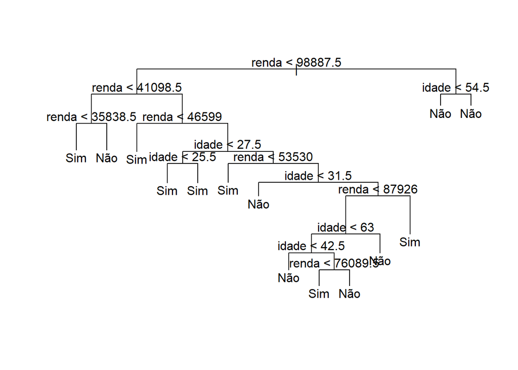

```r
library(tree)
set.seed(123)
dados <- data.frame(
  idade = sample(20:70, 100, replace = TRUE),
  renda = sample(30000:120000, 100, replace = TRUE),
  cliente = factor(sample(c("Sim", "Não"), 100, replace = TRUE))
)

modelo_arvore <- tree(cliente ~ idade + renda, data = dados)
plot(modelo_arvore)
text(modelo_arvore, pretty = 0)
```

## 23.2 Random Forest

O Random Forest é uma extensão das árvores de decisão, onde várias árvores são construídas a partir de amostras diferentes dos dados. A classificação final é obtida pela votação da maioria das árvores.

### 23.2.1 Vantagens do Random Forest

- Redução do overfitting comparado a uma única árvore.
- Melhor performance em conjuntos de dados grandes e com muitas variáveis.

## 23.3 Logit Multinomial

O Logit Multinomial é usado para modelar variáveis dependentes com mais de duas categorias. Ele estende o modelo logístico binário para múltiplas classes.

### 23.3.1 Exemplo Prático

O modelo Logit Multinomial pode ser usado para prever a escolha de produtos bancários com base em características do cliente.

```r
# Exemplo de Logit Multinomial
library(nnet)

# Dados de exemplo
dados_logit <- data.frame(
  produto = factor(c("A", "B", "C", "A", "B", "C", "A", "C")),
  idade = c(25, 45, 35, 50, 23, 30, 37, 48),
  renda = c(50000, 60000, 70000, 80000, 40000, 75000, 90000, 120000)
)

# Modelo Logit Multinomial
modelo_logit <- multinom(produto ~ idade + renda, data = dados_logit)
# Resumo do modelo
summary(modelo_logit)
```

```
## Call:
## multinom(formula = produto ~ idade + renda, data = dados_logit)
##
## Coefficients:
##   (Intercept)      idade         renda
## B   25.622772  1.8302245 -1.549108e-03
## C   -1.347801 -0.1505384  8.632231e-05
##
## Std. Errors:
##    (Intercept)        idade        renda
## B 4.687663e-09 1.416358e-07 2.458451e-04
## C 4.193482e-10 7.553388e-09 1.186299e-05
##
## Residual Deviance: 6.652845
## AIC: 18.65285
```

# 24 Definição de Tamanho Amostral

Nesta aula, exploramos métodos para determinar o tamanho amostral adequado para estudos estatísticos, garantindo precisão e poder do teste desejado.

## 24.1 Importância do Tamanho Amostral

Determinar o tamanho amostral correto é essencial para assegurar que o estudo tenha poder estatístico suficiente para detectar efeitos significativos, evitando amostras sub ou superdimensionadas.

### 24.1.1 Fórmula Geral para Tamanho Amostral

Para uma média populacional, a fórmula do tamanho amostral $n$ é dada por:

$$n = \left( \frac{Z_{\alpha/2} \cdot \sigma}{E} \right)^2$$

Onde: - $Z_{\alpha/2}$ é o valor crítico da distribuição normal para o nível de confiança desejado. - $\sigma$ é o desvio padrão estimado. - $E$ é o erro máximo aceitável.

### 24.1.2 Exemplo Prático

Suponha que queremos estimar a média de renda de uma população com um erro máximo de 5000 e um nível de confiança de 95%. O desvio padrão estimado é de 20000.

```r
# Parâmetros
z_alpha <- qnorm(0.975)  # Valor crítico para 95% de confiança
sigma <- 20000  # Desvio padrão estimado
erro <- 5000  # Erro máximo aceitável

# Cálculo do tamanho amostral
n <- (z_alpha * sigma / erro)^2
n
```

```
## [1] 61.46334
```

## 24.2 Cálculo para Proporções

Para proporções, a fórmula é:

$$n = \frac{Z_{\alpha/2}^2 \cdot p \cdot (1 - p)}{E^2}$$

Onde: - $p$ é a proporção estimada.

### 24.2.1 Exemplo Prático

Queremos estimar a proporção de clientes satisfeitos com uma precisão de 5% e um nível de confiança de 95%. Estimamos que 60% dos clientes estão satisfeitos.

```r
# Parâmetros
p <- 0.60  # Proporção estimada
z_alpha <- qnorm(0.975)
erro <- 0.05

# Cálculo do tamanho amostral
n_proporcao <- (z_alpha^2 * p * (1 - p)) / erro^2
n_proporcao
```

```
## [1] 368.78
```

# 25 Referências

1. **Playlist de Aulas - Inferência Estatística do Canal do Professor Rodrigo Pavão**
   - Disponível em: [Playlist de Aulas](https://www.youtube.com/@PavaoRodrigo/playlists)
2. **Slides e Scripts usados nas aulas**
   - Link: [Slides e Scripts](https://bit.ly/slides_scripts)
3. **Livro:** [Estatística Prática Para Cientistas de Dados](https://a.co/d/4Eb9whV)
   - Autor: Peter Bruce & Andrew Bruce
4. **Livro:** [R para Data Science](https://a.co/d/eoWvYfo)
   - Autor: Hadley Wickham & Garrett Grolemund
5. **Livro:** [Análise Estatística com R para leigos](https://a.co/d/9WOtHQ4)
   - Autor: Joseph Schmuller
   - Referência da disciplina
6. **Livro:** [Estatística Básica](https://a.co/d/5N26HhR)
   - Autor: Wilton de O. Bussab & Pedro A. Morettin
   - Referência da disciplina
7. **Livro:** [Fundamental Statistics for the Behavioral Sciences](https://a.co/d/etMJQB0)
   - Autor: David C. Howell
   - Referência da disciplina